# Real Time Location System

### By Lauren Darr, Heidi Nguyen, Ghizlane Zerouali

## Introduction

Indoor positioning systems (IPS) can determine the location of an object or human by using a mobile device such as a cellphone or laptop to record signals to a known WiFi access point (routers). These hardware devices produce signals that provide location data. This location data is captured by other hardware devices that have softwares which use triangulation or trilateration algorithms to intepret this location data to identify the location of the object.

This case study was designed by Deborah Nolan and Duncan Temple Lang for "Data Science in R: A Case Studies Approach to Computational Reasoning and Problem Solving". The goal of this exercise is to utilize sensor data recorded inside a building by researchers at the University of Manneheim to develop a statistical model that can determine where an individual is in a building based on signal strength. In this case, the training data set was developed by taking millions of measurements of signal strength from known distances to routers in the building. This training data was explored and used in a K-Nearest Neighbors (KNN) approach in order to predict where a new individual may be based on signal data.

KNN is a non-parametric classification algorithm that is useful when not much is known about a data set. KNN is a lazy learner. This means that the training data set is not used to create a generalized model. Instead, each testing data point is compared to the training data set and then assigned the class it is closest to. It is assumed in KNN that a test point most likely belongs to the class of training points it is closest to.

## Data Information and Methods

The wireless data was collected by a hand-held device that measured signal strength from a variety of distances and 8 different orientations to 6 access points. These 6 access points are used for the k-nearest neighbors model. Repetitive measurements of signal strength were taken at each known (calibration) location. The floor plan of the floor is detailed in Nolan's and Lang's book and is assumed to be accurate.

In their analysis, Nolan and Temple Lang use an IPS using signal strength data and a mean-based k-nearest neighbors model. The model is used to predict the device location using unseen signal strength data.

The raw data is split into a training data set and a test data set. The training data set contains unique lines detailing the (x,y) position and orientation of a mobile device. Each position and orientation combination has 110 signal strength readings.POSIX time of the reading and the physical MAC address for each access point are also captured.

```python
# Read in data from online source

options(digits = 2)

txt = readLines("../offline.final.trace.txt")
```

```python
# The data is in string format and must be parsed in order to create a tabular data set.
#Sum the number of lines that start with a character comment '#'
sum(substr(txt, 1, 1) == "#")

#Sum the total number of lines in the file
length(txt)

#Split the the first line that isn't a comment by the semi-colons
strsplit(txt[4], ";")[[1]]

#Split the same line by the ';' '=' and ',' to create individual tokens
tokens = strsplit(txt[4], "[;=,]")[[1]]

# The first 10 elements of tokens give details about the hand-held device
tokens[1:10]

# extract the values of variables
tokens[c(2, 4, 6:8, 10)]

#Look at the recorded signals within the observation
tokens[ - ( 1:10 ) ]

#Create a matrix with the first 10 entries to confirm the shape
tmp = matrix(tokens[ - (1:10) ], ncol = 4, byrow = TRUE)
mat = cbind(matrix(tokens[c(2, 4, 6:8, 10)], nrow = nrow(tmp),
                   ncol = 6, byrow = TRUE),
            tmp)

dim(mat)

# Repeat the operation for each row in the input file
processLine =
function(x)
{
  tokens = strsplit(x, "[;=,]")[[1]]
  tmp = matrix(tokens[ - (1:10) ], ncol = 4, byrow = TRUE)
  cbind(matrix(tokens[c(2, 4, 6:8, 10)], nrow = nrow(tmp),
               ncol = 6, byrow = TRUE), tmp)}
```

5312

151392

1. 't=1139643118358'

2. 'id=00:02:2D:21:0F:33'

3. 'pos=0.0,0.0,0.0'

4. 'degree=0.0'

5. '00:14:bf:b1:97:8a=-38,2437000000,3'

6. '00:14:bf:b1:97:90=-56,2427000000,3'

7. '00:0f:a3:39:e1:c0=-53,2462000000,3'

8. '00:14:bf:b1:97:8d=-65,2442000000,3'

9. '00:14:bf:b1:97:81=-65,2422000000,3'

10. '00:14:bf:3b:c7:c6=-66,2432000000,3'

11. '00:0f:a3:39:dd:cd=-75,2412000000,3'

12. '00:0f:a3:39:e0:4b=-78,2462000000,3'

13. '00:0f:a3:39:e2:10=-87,2437000000,3'

14. '02:64:fb:68:52:e6=-88,2447000000,1'

15. '02:00:42:55:31:00=-84,2457000000,1'

1. 't'

2. '1139643118358'

3. 'id'

4. '00:02:2D:21:0F:33'

5. 'pos'

6. '0.0'

7. '0.0'

8. '0.0'

9. 'degree'

10. '0.0'

1. '1139643118358'

2. '00:02:2D:21:0F:33'

3. '0.0'

4. '0.0'

5. '0.0'

6. '0.0'

1. '00:14:bf:b1:97:8a'

2. '-38'

3. '2437000000'

4. '3'

5. '00:14:bf:b1:97:90'

6. '-56'

7. '2427000000'

8. '3'

9. '00:0f:a3:39:e1:c0'

10. '-53'

11. '2462000000'

12. '3'

13. '00:14:bf:b1:97:8d'

14. '-65'

15. '2442000000'

16. '3'

17. '00:14:bf:b1:97:81'

18. '-65'

19. '2422000000'

20. '3'

21. '00:14:bf:3b:c7:c6'

22. '-66'

23. '2432000000'

24. '3'

25. '00:0f:a3:39:dd:cd'

26. '-75'

27. '2412000000'

28. '3'

29. '00:0f:a3:39:e0:4b'

30. '-78'

31. '2462000000'

32. '3'

33. '00:0f:a3:39:e2:10'

34. '-87'

35. '2437000000'

36. '3'

37. '02:64:fb:68:52:e6'

38. '-88'

39. '2447000000'

40. '1'

41. '02:00:42:55:31:00'

42. '-84'

43. '2457000000'

44. '1'

1. 11

2. 10

The raw data is split into a training data set and a test data set. The above table shows the training data set contains 151,392 lines of (x,y) location and orientation. For each line, 110 signal strength readings are obtained between the mobile device and the access points.

```python
# Create a function that parse each row in the input file and ultimately create a data frame
tmp = lapply(txt[4:20], processLine)

sapply(tmp, nrow)

offline = as.data.frame(do.call("rbind", tmp))
dim(offline)

# To process lines we will need to discard the lines starting with the comment character ‘#’
lines = txt[ substr(txt, 1, 1) != "#" ]
tmp = lapply(lines, processLine)

processLine = function(x)
{
  tokens = strsplit(x, "[;=,]")[[1]]

  if (length(tokens) == 10)
    return(NULL)

  tmp = matrix(tokens[ - (1:10) ], , 4, byrow = TRUE)
  cbind(matrix(tokens[c(2, 4, 6:8, 10)], nrow(tmp), 6,
               byrow = TRUE), tmp)
}

# Handle errors and change warnings into errors
options(error = recover, warn = 1)
tmp = lapply(lines, processLine)
offline = as.data.frame(do.call("rbind", tmp),
                        stringsAsFactors = FALSE)
```

1. 11

2. 10

3. 10

4. 11

5. 9

6. 10

7. 9

8. 9

9. 10

10. 11

11. 11

12. 9

13. 9

14. 9

15. 8

16. 10

17. 14

1. 170

2. 10

```python
# Cleaning the Data and creating a data structure for analysis
dim(offline)

# put meaningful names on the variables
names(offline) = c("time", "scanMac", "posX", "posY", "posZ",
                   "orientation", "mac", "signal",
                   "channel", "type")

# Identify the numeric values
numVars = c("time", "posX", "posY", "posZ",
            "orientation", "signal")
offline[ numVars ] =  lapply(offline[ numVars ], as.numeric)

offline = offline[ offline$type == "3", ]
offline = offline[ , "type" != names(offline) ]
dim(offline)

# Time conversion
offline$rawTime = offline$time
offline$time = offline$time/1000
class(offline$time) = c("POSIXt", "POSIXct")

unlist(lapply(offline, class))
```

1. 1181628

2. 10

1. 978443

2. 9

**time1**

'POSIXt'

**time2**

'POSIXct'

**scanMac**

'character'

**posX**

'numeric'

**posY**

'numeric'

**posZ**

'numeric'

**orientation**

'numeric'

**mac**

'character'

**signal**

'numeric'

**channel**

'character'

**rawTime**

'numeric'

The POSIX time of the reading and the physical MAC address for each access point are also recorded.

### Final Data Frame

The initial data frame has 1,181,628 rows and 10 columns. The previous output details the data type of each attribute. The previous code cell converted some of the variables to more appropriate data types. For example, time1 and time2 were changed to time data types ('POSIXt').

Furthermore, the original data frame includes 'adhoc' measurements that are removed from the dataframe because they do not represent measurements taken from fixed access points that are known. The 'type' variable is also removed. The final dataframe has 978,443 rows and 9 columns.

```
      time                          posX         posY           posZ
 Min.   :2006-02-11 01:31:58   Min.   : 0   Min.   : 0.0   Min.   :0
 1st Qu.:2006-02-11 07:21:27   1st Qu.: 2   1st Qu.: 3.0   1st Qu.:0
 Median :2006-02-11 13:57:58   Median :12   Median : 6.0   Median :0
 Mean   :2006-02-16 08:57:37   Mean   :14   Mean   : 5.9   Mean   :0
 3rd Qu.:2006-02-19 08:52:40   3rd Qu.:23   3rd Qu.: 8.0   3rd Qu.:0
 Max.   :2006-03-09 14:41:10   Max.   :33   Max.   :13.0   Max.   :0
  orientation      signal
 Min.   :  0   Min.   :-99
 1st Qu.: 90   1st Qu.:-69
 Median :180   Median :-60
 Mean   :167   Mean   :-62
 3rd Qu.:270   3rd Qu.:-53
 Max.   :360   Max.   :-25
```

```
                mac               channel                    scanMac
 00:0f:a3:39:e1:c0:145862   2462000000:189774   00:02:2D:21:0F:33:978443
 00:0f:a3:39:dd:cd:145619   2437000000:152124
 00:14:bf:b1:97:8a:132962   2412000000:145619
 00:14:bf:3b:c7:c6:126529   2432000000:126529
 00:14:bf:b1:97:90:122315   2427000000:122315
 00:14:bf:b1:97:8d:121325   2442000000:121325
 (Other)          :183831   (Other)   :120757
```

203

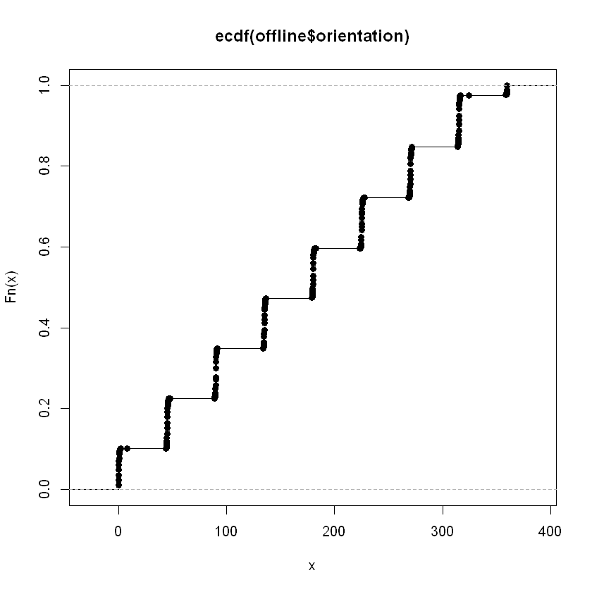

**null device:** 1

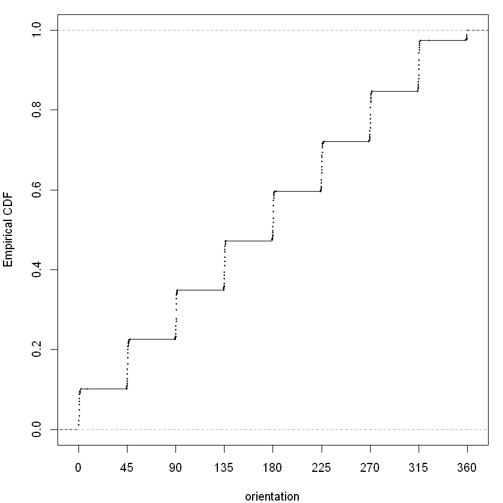

```python
# This code provides a summary table of the variables in the dataframe in order to verify that the values
# for each variable seem correct.
# The scanMac variable, which identifies the hand held device, is removed because all of the measurements were taken from the same device
# The posZ variable is removed because all of the measurements were taken from one floor of the building
summary(offline[, numVars])

 summary(sapply(offline[ , c("mac", "channel", "scanMac")],
                as.factor))

offline = offline[ , !(names(offline) %in% c("scanMac", "posZ"))]

length(unique(offline$orientation))

plot(ecdf(offline$orientation))

#pdf(file = "Geo_ECDFOrientation.pdf", width = 10, height = 7)
oldPar = par(mar = c(4, 4, 1, 1))
plot(ecdf(offline$orientation), pch = 19, cex = 0.3,
     xlim = c(-5, 365), axes = FALSE,
     xlab = "orientation", ylab = "Empirical CDF", main = "")
box()
axis(2)
axis(side = 1, at = seq(0, 360, by = 45))
par(oldPar)
dev.off()
```

### Orientation values

There should be 8 recorded orientation values taken at 45 degree increments from 0-315 degrees. The code below discovers there are 203 unique values for orientation. In order to explore why this is, the distribution of the orientation values is plotted below. The distribution plot below shows that the values are clustered around the expected orientation values. The orientation values are rounded and a new column is created.

**null device:** 1

**null device:** 1

[figure not shown]

```python
#pdf(file = "Geo_DensityOrientation.pdf", width = 10, height = 5)
oldPar = par(mar = c(4, 4, 1, 1))
plot(density(offline$orientation, bw = 2,sub="Caption for the figure"),
 xlab = "orientation", main = "")
title("Graph of the original orientation")

par(oldPar)
dev.off()

# Create the rounded angles
roundOrientation = function(angles) {
  refs = seq(0, by = 45, length  = 9)
  q = sapply(angles, function(o) which.min(abs(o - refs)))
  c(refs[1:8], 0)[q]
}

offline$angle = roundOrientation(offline$orientation)

#pdf(file = "Geo_BoxplotAngle.pdf", width = 10)
oldPar = par(mar = c(4, 4, 1, 1))

par(oldPar)
dev.off()
```

### MAC Address Confirmation

A MAC address or media access control address is unique to all network interface controllers. We think there should only be 6 access points. The following code finds there are extra access points. However, by looking at the number of observations for access points it is determined that 5-6 access points have very few observations and are likely elsewhere in the building, but not included in the experiment.

There is one to one mapping to the channels. Remove offline channels.

```python
# Find the number of MAC address and channel
c(length(unique(offline$mac)), length(unique(offline$channel)))

table(offline$mac)

subMacs = names(sort(table(offline$mac), decreasing = TRUE))[1:7]
offline = offline[ offline$mac %in% subMacs, ]

macChannel = with(offline, table(mac, channel))
apply(macChannel, 1, function(x) sum(x > 0))

offline = offline[ , "channel" != names(offline)]

# Exploring the Position of variables
locDF = with(offline,
             by(offline, list(posX, posY), function(x) x))
length(locDF)


sum(sapply(locDF, is.null))
```

1. 12

2. 8

```
00:04:0e:5c:23:fc 00:0f:a3:39:dd:cd 00:0f:a3:39:e0:4b 00:0f:a3:39:e1:c0
              418            145619             43508            145862
00:0f:a3:39:e2:10 00:14:bf:3b:c7:c6 00:14:bf:b1:97:81 00:14:bf:b1:97:8a
            19162            126529            120339            132962
00:14:bf:b1:97:8d 00:14:bf:b1:97:90 00:30:bd:f8:7f:c5 00:e0:63:82:8b:a9
           121325            122315               301               103
```

**00:0f:a3:39:dd:cd**

1

**00:0f:a3:39:e1:c0**

1

**00:14:bf:3b:c7:c6**

1

**00:14:bf:b1:97:81**

1

**00:14:bf:b1:97:8a**

1

**00:14:bf:b1:97:8d**

1

**00:14:bf:b1:97:90**

1

476

310

### Position of handheld device and signal count

There are missing values for some positions- remove these elements.

The graph below shows the counts of signals detected at each location chosen by the investigator. There were 6 access points, 110 replications, and 8 angles for a total expected 5280 signals received.

166

'matrix'

1. 3

2. 166

| posX | 0 | 1 | 2 | 0 | 1 | 2 | 0 | 1 |
| --- | --- | --- | --- | --- | --- | --- | --- | --- |
| posY | 0 | 0 | 0 | 1 | 1 | 1 | 2 | 2 |
| count | 5505 | 5505 | 5506 | 5524 | 5543 | 5558 | 5503 | 5564 |

**null device:** 1

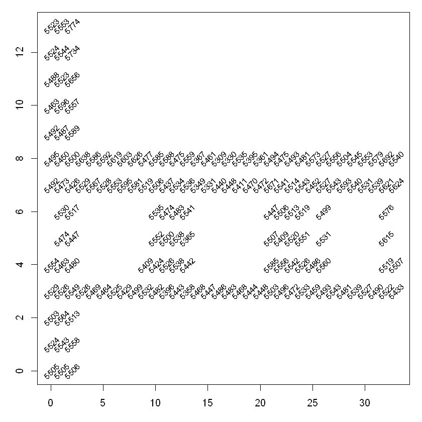

```python
locDF = locDF[ !sapply(locDF, is.null) ]

length(locDF)

locCounts = sapply(locDF, nrow)

locCounts = sapply(locDF,
                   function(df)
                     c(df[1, c("posX", "posY")], count = nrow(df)))

class(locCounts)

dim(locCounts)

locCounts[ , 1:8]

#pdf(file = "Geo_XYByCount.pdf", width = 10)
oldPar = par(mar = c(3.1, 3.1, 1, 1))

locCounts = t(locCounts)
plot(locCounts, type = "n", xlab = "", ylab = "")
text(locCounts, labels = locCounts[,3], cex = .8, srt = 45)

par(oldPar)
dev.off()
```

```python
# function verification
readData =
  function(filename = '../Downloads/offline.final.trace.txt',
           subMacs = c("00:0f:a3:39:e1:c0", "00:0f:a3:39:dd:cd", "00:14:bf:b1:97:8a",
                       "00:14:bf:3b:c7:c6", "00:14:bf:b1:97:90", "00:14:bf:b1:97:8d",
                       "00:14:bf:b1:97:81"))
  {
    txt = readLines(filename)
    lines = txt[ substr(txt, 1, 1) != "#" ]
    tmp = lapply(lines, processLine)
    offline = as.data.frame(do.call("rbind", tmp),
                            stringsAsFactors= FALSE)

    names(offline) = c("time", "scanMac",
                       "posX", "posY", "posZ", "orientation",
                       "mac", "signal", "channel", "type")

     # keep only signals from access points
    offline = offline[ offline$type == "3", ]

    # drop scanMac, posZ, channel, and type - no info in them
    dropVars = c("scanMac", "posZ", "channel", "type")
    offline = offline[ , !( names(offline) %in% dropVars ) ]

    # drop more unwanted access points
    offline = offline[ offline$mac %in% subMacs, ]

    # convert numeric values
    numVars = c("time", "posX", "posY", "orientation", "signal")
    offline[ numVars ] = lapply(offline[ numVars ], as.numeric)

    # convert time to POSIX
    offline$rawTime = offline$time
    offline$time = offline$time/1000
    class(offline$time) = c("POSIXt", "POSIXct")

    # round orientations to nearest 45
    offline$angle = roundOrientation(offline$orientation)

    return(offline)
  }

offlineRedo = readData()

identical(offline, offlineRedo)
```

TRUE

### Signal Strength Analysis

**null device:** 1

```
   Min. 1st Qu.  Median    Mean 3rd Qu.    Max.
    -98     -67     -59     -60     -53     -25
```

**null device:** 1

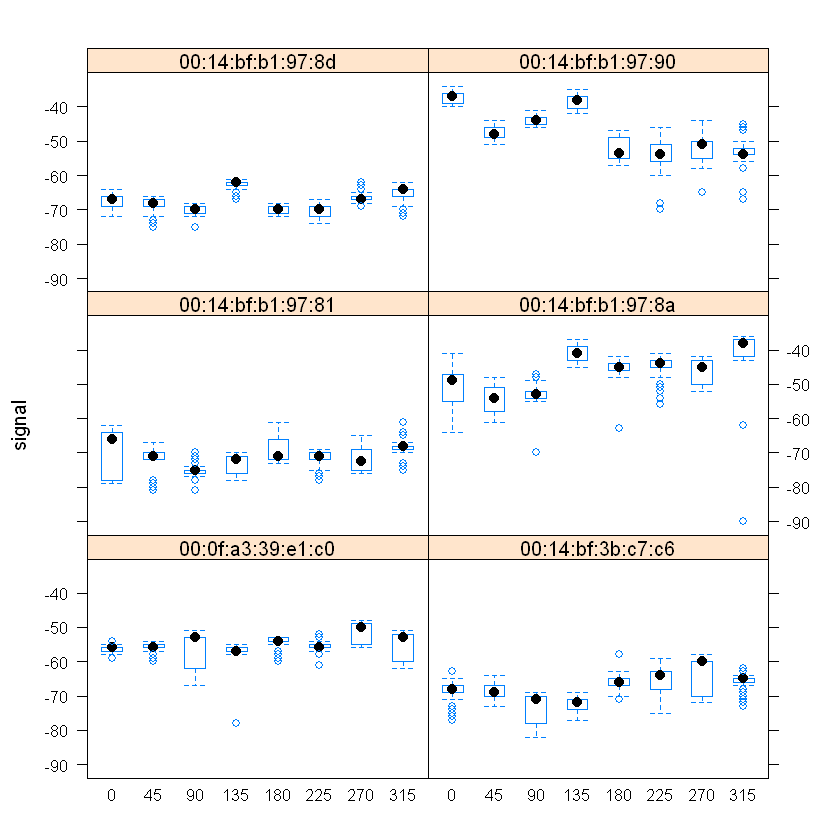

```python
# Comparing the distribution of signal strength at different orientations and for different access points
#pdf(file = "Geo_BoxplotSignalByMacAngle.pdf", width = 7)
oldPar = par(mar = c(3.1, 3, 1, 1))

library(lattice)
bwplot(signal ~ factor(angle) | mac, data = offline,
       subset = posX == 2 & posY == 12
                & mac != "00:0f:a3:39:dd:cd",
       layout = c(2,3))

par(oldPar)
dev.off()

summary(offline$signal)

#pdf(file = "Geo_DensitySignalByMacAngle.pdf", width = 8, height = 12)
oldPar = par(mar = c(3.1, 3, 1, 1))

densityplot( ~ signal | mac + factor(angle), data = offline,
             subset = posX == 24 & posY == 4 &
                         mac != "00:0f:a3:39:dd:cd",
             bw = 0.5, plot.points = FALSE)

par(oldPar)
dev.off()
```

The above boxplots present the examination of distribution of signal strength by Angle for Each Access Point for one location with the coordinations x = 2 and y = 12. The boxplots show a strong dependence of signal strength on angle of the access points. It is remarkable from the boxplots that there some observtions look normal while many others look skewed left.

The following test is used to examine the distribution of signal strength for all 166 locations, 8 angles, and 6 access points.

```python
# Preparing Data for k-nearest neighbors model

#offline = offline[ offline$mac != "00:0f:a3:39:dd:cd", ]

offline$posXY = paste(offline$posX, offline$posY, sep = "-")

# Create a list of data frames
byLocAngleAP = with(offline,
                    by(offline, list(posXY, angle, mac),
                       function(x) x))

# statistics summary
signalSummary =
  lapply(byLocAngleAP,
         function(oneLoc) {
           ans = oneLoc[1, ]
           ans$medSignal = median(oneLoc$signal)
           ans$avgSignal = mean(oneLoc$signal)
           ans$num = length(oneLoc$signal)
           ans$sdSignal = sd(oneLoc$signal)
           ans$iqrSignal = IQR(oneLoc$signal)
           ans
           })

# combine all the summary together
offlineSummary = do.call("rbind", signalSummary)
```

### The mean and The standard deviation

**null device:** 1

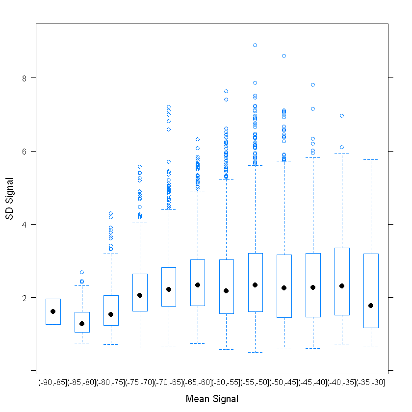

```python
# box plot for standard deviation for each averaged signal
#pdf(file = "Geo_BoxplotSignalSDByAvg.pdf", width = 10)
oldPar = par(mar = c(3.1, 3, 1, 1))

breaks = seq(-90, -30, by = 5)
bwplot(sdSignal ~ cut(avgSignal, breaks = breaks),
       data = offlineSummary,
       subset = mac != "00:0f:a3:39:dd:cd",
       xlab = "Mean Signal", ylab = "SD Signal")

par(oldPar)
dev.off()
```

### Comparison of Mean and Median Signal Strength

**null device:** 1

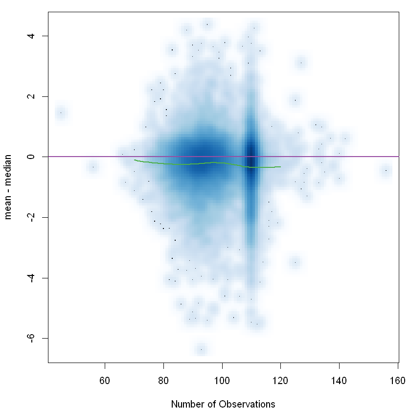

```python
# define the difference between Mean and Median
#pdf(file = "Geo_ScatterMean-Median.pdf", width = 10)
oldPar = par(mar = c(4.1, 4.1, 1, 1))

with(offlineSummary,
     smoothScatter((avgSignal - medSignal) ~ num,
                   xlab = "Number of Observations",
                   ylab = "mean - median"))
abline(h = 0, col = "#984ea3", lwd = 2)

lo.obj =
  with(offlineSummary,
       loess(diff ~ num,
             data = data.frame(diff = (avgSignal - medSignal),
                               num = num)))

# Prediction of the difference for each value
lo.obj.pr = predict(lo.obj, newdata = data.frame(num = (70:120)))
lines(x = 70:120, y = lo.obj.pr, col = "#4daf4a", lwd = 2)

par(oldPar)
dev.off()

# Choose the MAC adress and the angle
oneAPAngle = subset(offlineSummary,
                    mac == subMacs[5] & angle == 0)
```

We can see in the above figure that skewness is minimal, the data is rather normal, with higher densities in center. After fitting LOESS line, it shows that there is not a lot of difference or trend

Now we need to do the analysis of Extraneous MAC Address & Relationship Between Signal and Distance

### The Relationship between Signal and Distance

[output not shown]

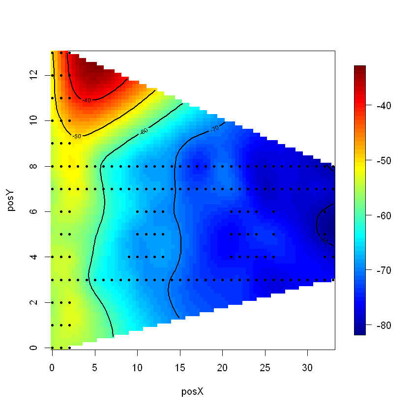

```python
# Fit a smooth surface to mean signal strength
# contour plot investigation
# one MAC and one orientaiton
library(fields)
smoothSS = Tps(oneAPAngle[, c("posX","posY")],
               oneAPAngle$avgSignal)

# Predict the value for the fitted surface
vizSmooth = predictSurface(smoothSS)

# Plot the predicted signal strength
plot.surface(vizSmooth, type = "C")

points(oneAPAngle$posX, oneAPAngle$posY, pch=19, cex = 0.5)
```

```python
# Summarize the MAC adresses
unique(offlineSummary$mac)
```

1. '00:0f:a3:39:e1:c0'

2. '00:14:bf:3b:c7:c6'

3. '00:14:bf:b1:97:81'

4. '00:14:bf:b1:97:8a'

5. '00:14:bf:b1:97:8d'

6. '00:14:bf:b1:97:90'

The heat map plot shows the location of the location of the access point of signal strength as the dark red region at the top of the plot for a MAC adress of 00:14:bf:b1:97:90.

[output not shown]

[output cut: 48 more lines]

[output not shown]

[output not shown]

|  | x | y |
| --- | --- | --- |
| 00:0f:a3:39:e1:c0 | 7.5 | 6.3 |
| 00:14:bf:b1:97:8a | 2.5 | -0.8 |
| 00:14:bf:3b:c7:c6 | 12.8 | -2.8 |
| 00:14:bf:b1:97:90 | 1.0 | 14.0 |
| 00:14:bf:b1:97:8d | 33.5 | 9.3 |
| 00:14:bf:b1:97:81 | 33.5 | 2.8 |

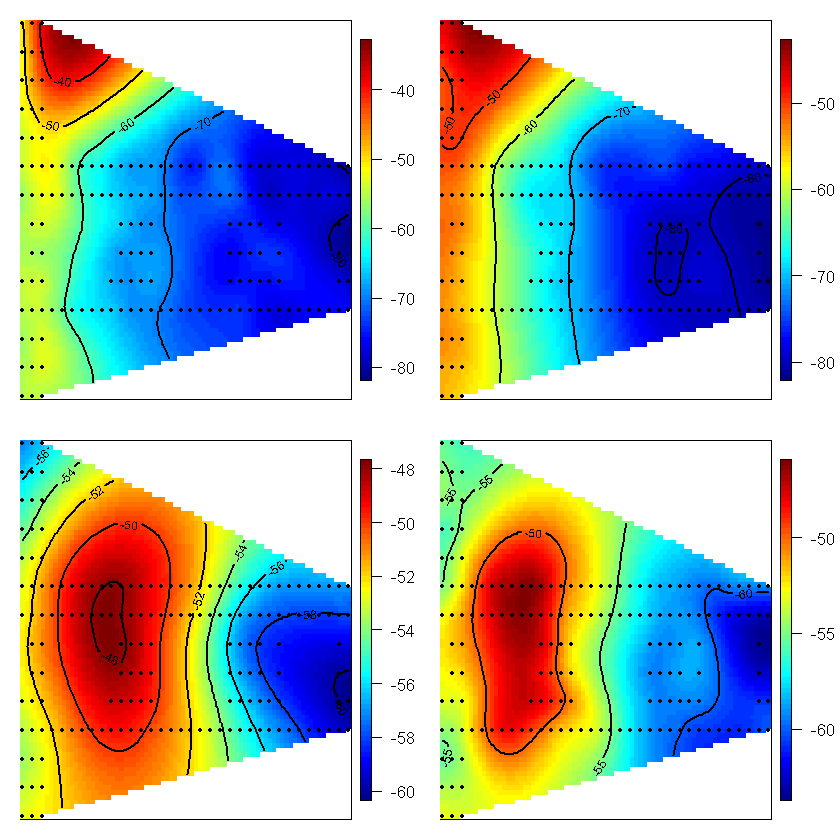

```python
surfaceSS = function(data, mac, angle = 45) {
  require(fields)
  oneAPAngle = data[ data$mac == mac & data$angle == angle, ]
  smoothSS = Tps(oneAPAngle[, c("posX","posY")],
                 oneAPAngle$avgSignal)
  vizSmooth = predictSurface(smoothSS)
  plot.surface(vizSmooth, type = "C",
               xlab = "", ylab = "", xaxt = "n", yaxt = "n")
  points(oneAPAngle$posX, oneAPAngle$posY, pch=19, cex = 0.5)
}

parCur = par(mfrow = c(2,2), mar = rep(1, 4))

mapply(surfaceSS, mac = subMacs[ rep(c(5, 1), each = 2) ],
       angle = rep(c(0, 135), 2),
       data = list(data = offlineSummary))

par(parCur)

# exclude mac at position 2
offlineSummary = subset(offlineSummary, mac != subMacs[2])

# Create a small matrix
AP = matrix( c( 7.5, 6.3, 2.5, -.8, 12.8, -2.8,
                1, 14, 33.5, 9.3,  33.5, 2.8),
            ncol = 2, byrow = TRUE,
            dimnames = list(subMacs[ -2 ], c("x", "y") ))

AP
```

The transformed data set is aggregated by (x,y) position, angle, and MAC address. It's observed that there is higher variability for stronger signal strengths. There is also negative corelation between signal and distance where signal strength weakens as distance increases. This negative relationship is expected and can be seen in the below figures.

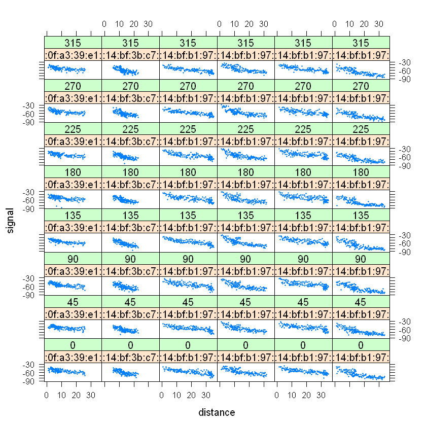

**null device:** 1

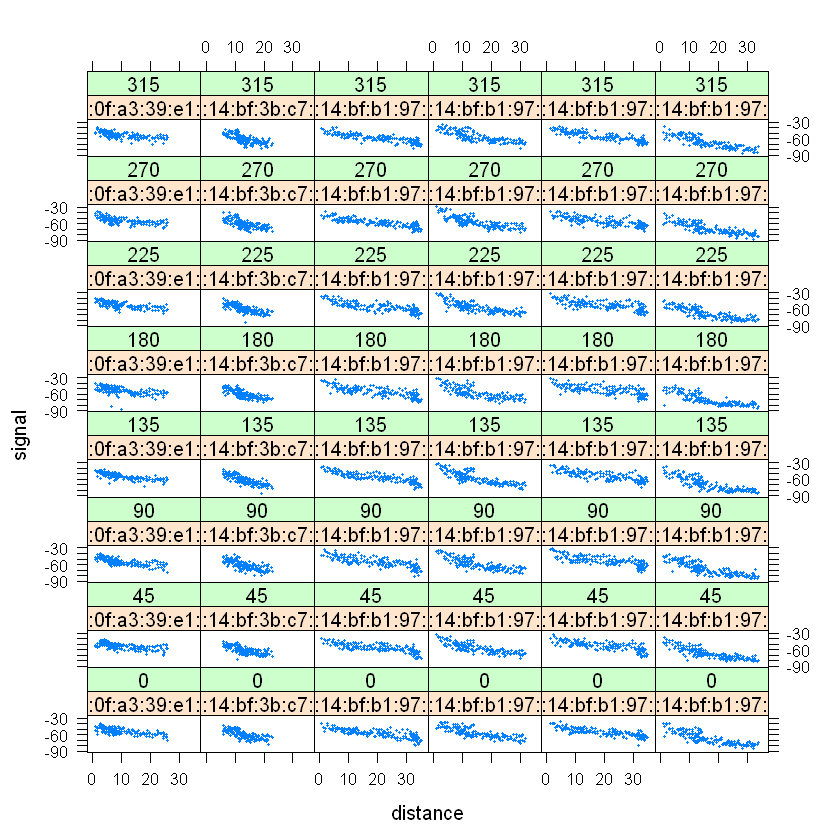

```python
# Examine the relationship between signal strength and distance from the access point
# Find the Euclidean distance between the position of the hand-held device and the access point
# Make a series of scatter plots for each access point and device orientation
diffs = offlineSummary[ , c("posX", "posY")] -
          AP[ offlineSummary$mac, ]

offlineSummary$dist = sqrt(diffs[ , 1]^2 + diffs[ , 2]^2)

xyplot(signal ~ dist | factor(mac) + factor(angle),
       data = offlineSummary, pch = 19, cex = 0.3,
       xlab ="distance")

#pdf(file="Geo_ScatterSignalDist.pdf", width = 7, height = 10)
oldPar = par(mar = c(3.1, 3.1, 1, 1))
library(lattice)
xyplot(signal ~ dist | factor(mac) + factor(angle),
       data = offlineSummary, pch = 19, cex = 0.3,
       xlab ="distance")
par(oldPar)
dev.off()

macs = unique(offlineSummary$mac)
```

The transformed data set is subsequently aggregated by (x,y) position, angle, and MAC address. Additional analysis using the aggregated data set shows higher variability for stronger signal strengths. Also, the relationship between signal and distance shows that signal strength weakens as distance increases. This negative relationship is expected and can be seen for each access point in the above figure

To prepare for the training and test data sets for use in a k-nearest neighbors model, we first aggregate the data by (x,y) position to form a data set where each record is unique, based on (x,y) position. Each position is associated with a vector of six signal strength values. The signal strengths from each access point at each position are mean-aggregated

### Preparing the Test Data

```python
online = readData("../Downloads/online.final.trace.txt", subMacs = macs)

online$posXY = paste(online$posX, online$posY, sep = "-")

length(unique(online$posXY))

tabonlineXYA = table(online$posXY, online$angle)
tabonlineXYA[1:6, ]

keepVars = c("posXY", "posX","posY", "orientation", "angle")
byLoc = with(online,
             by(online, list(posXY),
                function(x) {
                  ans = x[1, keepVars]
                  avgSS = tapply(x$signal, x$mac, mean)
                  y = matrix(avgSS, nrow = 1, ncol = 6,
                        dimnames = list(ans$posXY, names(avgSS)))
                  cbind(ans, y)
                }))

onlineSummary = do.call("rbind", byLoc)
```

60

```
               0  45  90 135 180 225 270 315
  0-0.05       0   0   0 593   0   0   0   0
  0.15-9.42    0   0 606   0   0   0   0   0
  0.31-11.09   0   0   0   0   0 573   0   0
  0.47-8.2   590   0   0   0   0   0   0   0
  0.78-10.94 586   0   0   0   0   0   0   0
  0.93-11.69   0   0   0   0 583   0   0   0
```

```python
# find records in training data set that have similar orientations to our new observations
# again, proving that orientation affects signal strength

# finding nearest angles to help filter training data before aggregation:
dim(onlineSummary)

names(onlineSummary)
m = 3; angleNewObs = 230
refs = seq(0, by = 45, length  = 8)
nearestAngle = roundOrientation(angleNewObs)

if (m %% 2 == 1) {
  angles = seq(-45 * (m - 1) /2, 45 * (m - 1) /2, length = m)
} else {
  m = m + 1
  angles = seq(-45 * (m - 1) /2, 45 * (m - 1) /2, length = m)
  if (sign(angleNewObs - nearestAngle) > -1)
    angles = angles[ -1 ]
  else
    angles = angles[ -m ]
}
angles = angles + nearestAngle
angles[angles < 0] = angles[ angles < 0 ] + 360
angles[angles > 360] = angles[ angles > 360 ] - 360
```

1. 60

2. 11

1. 'posXY'

2. 'posX'

3. 'posY'

4. 'orientation'

5. 'angle'

6. '00:0f:a3:39:e1:c0'

7. '00:14:bf:3b:c7:c6'

8. '00:14:bf:b1:97:81'

9. '00:14:bf:b1:97:8a'

10. '00:14:bf:b1:97:8d'

11. '00:14:bf:b1:97:90'

The new data frame has 60 rows and 11 variables, including 6 average signal strengths at the corresponding MAC addresses. The column names are summarized in the second line of the results.

```python
# select observations from offlineSummary for training
offlineSubset =
  offlineSummary[ offlineSummary$angle %in% angles, ]

reshapeSS = function(data, varSignal = "signal",
                     keepVars = c("posXY", "posX","posY")) {
  byLocation =
    with(data, by(data, list(posXY),
                  function(x) {
                    ans = x[1, keepVars]
                    avgSS = tapply(x[ , varSignal ], x$mac, mean)
                    y = matrix(avgSS, nrow = 1, ncol = 6,
                               dimnames = list(ans$posXY,
                                               names(avgSS)))
                    cbind(ans, y)
                  }))

  newDataSS = do.call("rbind", byLocation)
  return(newDataSS)
}

# reshape training set to match test set, with signals across columns
trainSS = reshapeSS(offlineSubset, varSignal = "avgSignal")
```

```python
# select angles and reshape the training set
# signals is the training dataset to filter and reshape
selectTrain = function(angleNewObs, signals = NULL, m = 1){
  # m is the number of angles to keep between 1 and 5
  refs = seq(0, by = 45, length  = 8)
  nearestAngle = roundOrientation(angleNewObs)

  if (m %% 2 == 1)
    angles = seq(-45 * (m - 1) /2, 45 * (m - 1) /2, length = m)
  else {
    m = m + 1
    angles = seq(-45 * (m - 1) /2, 45 * (m - 1) /2, length = m)
    if (sign(angleNewObs - nearestAngle) > -1)
      angles = angles[ -1 ]
    else
      angles = angles[ -m ]
  }
  angles = angles + nearestAngle
  angles[angles < 0] = angles[ angles < 0 ] + 360
  angles[angles > 360] = angles[ angles > 360 ] - 360
  angles = sort(angles)

  offlineSubset = signals[ signals$angle %in% angles, ]
  reshapeSS(offlineSubset, varSignal = "avgSignal")
}
```

Use angle of 130 for offline summary taking 135 and two closest angles for training set and reshape by aggregating, taking average of signals for each mac, and angles are considered.

## KNN Weights

```python
# Find nearest mean average neighbors

# training data for each new observation (with 3 angles)
train130 = selectTrain(130, offlineSummary, m = 3)

head(train130)

length(train130[[1]])

findNN = function(newSignal, trainSubset) {
  diffs = apply(trainSubset[ , 4:9], 1,
                function(x) x - newSignal)
  dists = apply(diffs, 2, function(x) sqrt(sum(x^2)) )
  closest = order(dists)
  return(trainSubset[closest, 1:3 ])
}
```

|  | posXY | posX | posY | 00:0f:a3:39:e1:c0 | 00:14:bf:3b:c7:c6 | 00:14:bf:b1:97:81 | 00:14:bf:b1:97:8a | 00:14:bf:b1:97:8d | 00:14:bf:b1:97:90 |
| --- | --- | --- | --- | --- | --- | --- | --- | --- | --- |
| 0-0 | 0-0 | 0 | 0 | -52 | -66 | -63 | -36 | -64 | -55 |
| 0-1 | 0-1 | 0 | 1 | -53 | -65 | -64 | -39 | -65 | -59 |
| 0-10 | 0-10 | 0 | 10 | -56 | -66 | -69 | -45 | -67 | -50 |
| 0-11 | 0-11 | 0 | 11 | -55 | -67 | -70 | -48 | -67 | -55 |
| 0-12 | 0-12 | 0 | 12 | -56 | -70 | -72 | -45 | -67 | -50 |
| 0-13 | 0-13 | 0 | 13 | -55 | -71 | -73 | -43 | -69 | -54 |

166

```python
# prediction
# takes an input of newSignals, their angles, and returns the estimated positions
predXY = function(newSignals, newAngles, trainData,
                  numAngles = 1, k = 3){

  closeXY = list(length = nrow(newSignals))

  for (i in 1:nrow(newSignals)) {
    trainSS = selectTrain(newAngles[i], trainData, m = numAngles)
    closeXY[[i]] =
      findNN(newSignal = as.numeric(newSignals[i, ]), trainSS)
  }

  estXY = lapply(closeXY,
                 function(x) sapply(x[ , 2:3],
                                    function(x) mean(x[1:k])))
  estXY = do.call("rbind", estXY)
  return(estXY)
}
estXYk3 = predXY(newSignals = onlineSummary[ , 6:11],
                 newAngles = onlineSummary[ , 4],
                 offlineSummary, numAngles = 3, k = 3)

estXYk1 = predXY(newSignals = onlineSummary[ , 6:11],
                 newAngles = onlineSummary[ , 4],
                 offlineSummary, numAngles = 3, k = 1)
```

```python
# errors on the floor
floorErrorMap = function(estXY, actualXY, trainPoints = NULL, AP = NULL){

    plot(0, 0, xlim = c(0, 35), ylim = c(-3, 15), type = "n",
         xlab = "", ylab = "", axes = FALSE)
    box()
    if ( !is.null(AP) ) points(AP, pch = 15)
    if ( !is.null(trainPoints) )
      points(trainPoints, pch = 19, col="grey", cex = 0.6)

    points(x = actualXY[, 1], y = actualXY[, 2],
           pch = 19, cex = 0.8 )
    points(x = estXY[, 1], y = estXY[, 2],
           pch = 8, cex = 0.8 )
    segments(x0 = estXY[, 1], y0 = estXY[, 2],
             x1 = actualXY[, 1], y1 = actualXY[ , 2],
             lwd = 2, col = "red")
}

trainPoints = offlineSummary[ offlineSummary$angle == 0 &
                              offlineSummary$mac == "00:0f:a3:39:e1:c0" ,
                        c("posX", "posY")]
```

**null device:** 1

**null device:** 1

1. 659.4003

2. 306.702522222222

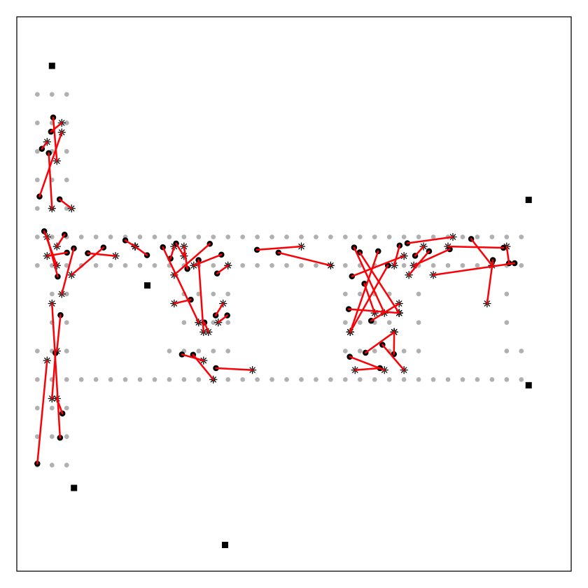

```python
# Floor Level Errors
#pdf(file="GEO_FloorPlanK3Errors.pdf", width = 10, height = 7)
oldPar = par(mar = c(1, 1, 1, 1))
floorErrorMap(estXYk3, onlineSummary[ , c("posX","posY")],
              trainPoints = trainPoints, AP = AP)
par(oldPar)
dev.off()

#pdf(file="GEO_FloorPlanK1Errors.pdf", width = 10, height = 7)
oldPar = par(mar = c(1, 1, 1, 1))
floorErrorMap(estXYk1, onlineSummary[ , c("posX","posY")],
              trainPoints = trainPoints, AP = AP)
par(oldPar)
dev.off()

# Calculate Error
calcError =
function(estXY, actualXY)
   sum( rowSums( (estXY - actualXY)^2) )

actualXY = onlineSummary[ , c("posX", "posY")]
sapply(list(estXYk1, estXYk3), calcError, actualXY)
```

### These plots show the predicted values connected to the test locations. The black dots are the test locations and the astericks are the predicted values.

```python
v = 11
permuteLocs = sample(unique(offlineSummary$posXY))
permuteLocs = matrix(permuteLocs, ncol = v,
                     nrow = floor(length(permuteLocs)/v))

onlineFold = subset(offlineSummary, posXY %in% permuteLocs[ , 1])

reshapeSS = function(data, varSignal = "signal",
                     keepVars = c("posXY", "posX","posY"),
                     sampleAngle = FALSE,
                     refs = seq(0, 315, by = 45)) {
  byLocation =
    with(data, by(data, list(posXY),
                  function(x) {
                    if (sampleAngle) {
                      x = x[x$angle == sample(refs, size = 1), ]}
                    ans = x[1, keepVars]
                    avgSS = tapply(x[ , varSignal ], x$mac, mean)
                    y = matrix(avgSS, nrow = 1, ncol = 6,
                               dimnames = list(ans$posXY,
                                               names(avgSS)))
                    cbind(ans, y)
                  }))

  newDataSS = do.call("rbind", byLocation)
  return(newDataSS)
}
```

```python
offline = offline[ offline$mac != "00:0f:a3:39:dd:cd", ]

keepVars = c("posXY", "posX","posY", "orientation", "angle")

onlineCVSummary = reshapeSS(offline, keepVars = keepVars,
                            sampleAngle = TRUE)

onlineFold = subset(onlineCVSummary,
                    posXY %in% permuteLocs[ , 1])

offlineFold = subset(offlineSummary,
                     posXY %in% permuteLocs[ , -1])

estFold = predXY(newSignals = onlineFold[ , 6:11],
                 newAngles = onlineFold[ , 4],
                 offlineFold, numAngles = 3, k = 3)
```

```python
actualFold = onlineFold[ , c("posX", "posY")]
calcError(estFold, actualFold)

K = 20
err = rep(0, K)

for (j in 1:v) {
  onlineFold = subset(onlineCVSummary,
                      posXY %in% permuteLocs[ , j])
  offlineFold = subset(offlineSummary,
                       posXY %in% permuteLocs[ , -j])
  actualFold = onlineFold[ , c("posX", "posY")]

  for (k in 1:K) {
    estFold = predXY(newSignals = onlineFold[ , 6:11],
                     newAngles = onlineFold[ , 4],
                     offlineFold, numAngles = 3, k = k)
    err[k] = err[k] + calcError(estFold, actualFold)
  }
}
```

209.777777777778

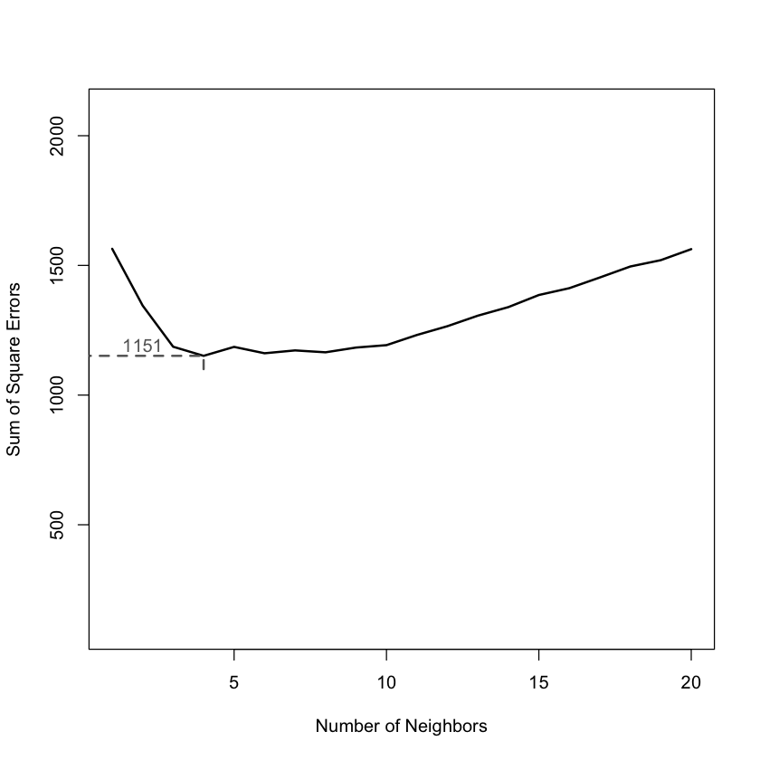

```python
#pdf(file = "Geo_CVChoiceOfK.pdf", width = 10, height = 6)
#oldPar = par(mar = c(4, 3, 1, 1))
plot(y = err, x = (1:K),  type = "l", lwd= 2,
     ylim = c(100, 2100),
     xlab = "Number of Neighbors",
     ylab = "Sum of Square Errors")

rmseMin = min(err)
kMin = which(err == rmseMin)[1]
segments(x0 = 0, x1 = kMin, y0 = rmseMin, col = gray(0.4),
         lty = 2, lwd = 2)
segments(x0 = kMin, x1 = kMin, y0 = 1100,  y1 = rmseMin,
         col = grey(0.4), lty = 2, lwd = 2)
text(x = kMin - 2, y = rmseMin + 40,
     label = as.character(round(rmseMin)), col = grey(0.4))
#par(oldPar)
#dev.off()
```

```python
#mtext(kMin, side = 1, line = 1, at = kMin, col = grey(0.4))


estXYk5 = predXY(newSignals = onlineSummary[ , 6:11],
                 newAngles = onlineSummary[ , 4],
                 offlineSummary, numAngles = 3, k = 5)

calcError(estXYk5, actualXY)
```

275.5083

```python
predXY = function(newSignals, newAngles, trainData,
                  numAngles = 1, k = 3){

  closeXY = list(length = nrow(newSignals))

  for (i in 1:nrow(newSignals)) {
    trainSS = selectTrain(newAngles[i], trainData, m = numAngles)
    closeXY[[i]] = findNN(newSignal = as.numeric(newSignals[i, ]),
                           trainSS)
  }

  estXY = lapply(closeXY, function(x)
                            sapply(x[ , 2:3],
                                    function(x) mean(x[1:k])))
  estXY = do.call("rbind", estXY)
  return(estXY)
}
```